# fit_challenge

## INTRODUCTION

### FIT 143 Challenge

The Fit 143 challenge involves 143 days of tracking workout routine data which would be used to create data dashboards.

Workout routines tracked include Running, Push-ups, dumb-bell, sit-ups, bench-press, and jumping-jacks.

The data is stored on a Google Sheet that can be found here: https://docs.google.com/spreadsheets/d/133xo8gUubOxyeB9vTJabCg0aY8DysDvwrxLgWliqBgw/edit?usp=sharing

**Description of Columns in Dataset**

- Push-ups: Number of push-ups done each day
- Bench-press: Number of bench-presses done each day
- Squats: Number of squats done each day
- Distance run (miles): Distance covered running each day measured in miles
- Duration (minutes): Time taken to complete run measured in minutes
- Average pace (min/mile): Average time taken in minutes to complete one mile while running
- Calories: Amount of calories burnt while running measured in calories.
- Sit-ups: Number of sit-ups done each day
- Jumping jacks: Number of jumping jacks done each day
- Date: Date for each tracked activity

The Runkeeper app is used to track running and generate data.

```python
# import all packages and set plots to be embedded inline
import numpy as np
import pandas as pd
import matplotlib.pyplot as plt
import seaborn as sb
import os
import gc
import math
import sklearn
from sklearn.metrics import classification_report
from sklearn.metrics import confusion_matrix
from sklearn.metrics import accuracy_score
from sklearn.model_selection import train_test_split
from sklearn import model_selection
from sklearn.ensemble import RandomForestClassifier
from sklearn.discriminant_analysis import LinearDiscriminantAnalysis
%matplotlib inline
%config InlineBackend.figure_format = 'retina'
```

```python
# load in the dataset into a pandas dataframe, print statistics
fit = pd.read_csv('fit.csv')
fit.sample(10)
```

|  | push_ups | bench_press | dumb_bell | squats | distance_run (miles) | duration (minutes) | average_pace (min/mile) | calories | sit_ups | jumping_jacks | date |
| --- | --- | --- | --- | --- | --- | --- | --- | --- | --- | --- | --- |
| 12 | 35 | 60.0 | 20.0 | 20.0 | 1.30 | 15.00 | 11.35 | 150.0 | 100.0 | 50.0 | 8/23/2020 |
| 19 | 35 | 60.0 | 20.0 | 25.0 | 1.32 | 13.57 | 10.34 | 157.0 | 100.0 | 50.0 | 9/4/2020 |
| 5 | 20 | 60.0 | 30.0 | 20.0 | 1.12 | 17.39 | 14.36 | 134.0 | 50.0 | NaN | 8/16/2020 |
| 8 | 35 | 100.0 | 20.0 | 20.0 | 1.23 | 16.50 | 13.41 | 138.0 | 100.0 | 50.0 | 8/19/2020 |
| 11 | 35 | 60.0 | 20.0 | 20.0 | 1.57 | 19.57 | 12.44 | 179.0 | 100.0 | 50.0 | 8/22/2020 |
| 18 | 35 | 110.0 | 20.0 | 25.0 | 1.34 | 14.01 | 10.27 | 160.0 | 200.0 | 50.0 | 9/3/2020 |
| 22 | 35 | 110.0 | 20.0 | 40.0 | 1.73 | 16.08 | 9.19 | 206.0 | 200.0 | 50.0 | 9/9/2020 |
| 7 | 35 | 60.0 | 20.0 | 20.0 | 1.23 | 20.14 | 16.28 | 130.0 | 100.0 | 50.0 | 8/18/2020 |
| 10 | 35 | 60.0 | 30.0 | 20.0 | 1.36 | 20.04 | 14.42 | 150.0 | 100.0 | 50.0 | 8/21/2020 |
| 2 | 30 | 110.0 | 20.0 | 25.0 | 1.11 | 21.22 | 19.18 | 121.0 | 165.0 | 50.0 | 8/13/2020 |

```python
fit.shape
```

```
(24, 11)
```

```python
fit.info()
```

```
<class 'pandas.core.frame.DataFrame'>
RangeIndex: 24 entries, 0 to 23
Data columns (total 11 columns):
push_ups                   24 non-null int64
bench_press                22 non-null float64
dumb_bell                  22 non-null float64
squats                     23 non-null float64
distance_run (miles)       22 non-null float64
duration (minutes)         22 non-null float64
average_pace (min/mile)    22 non-null float64
calories                   22 non-null float64
sit_ups                    22 non-null float64
jumping_jacks              22 non-null float64
date                       24 non-null object
dtypes: float64(9), int64(1), object(1)
memory usage: 2.1+ KB
```

```python
#missing data
total = fit.isnull().sum().sort_values(ascending=False)
percent = (fit.isnull().sum()/fit.isnull().count()).sort_values(ascending=False)
missing_data = pd.concat([total, percent], axis=1, keys=['Total', 'Percent'])
missing_data
```

|  | Total | Percent |
| --- | --- | --- |
| jumping_jacks | 2 | 0.083333 |
| sit_ups | 2 | 0.083333 |
| calories | 2 | 0.083333 |
| average_pace (min/mile) | 2 | 0.083333 |
| duration (minutes) | 2 | 0.083333 |
| distance_run (miles) | 2 | 0.083333 |
| dumb_bell | 2 | 0.083333 |
| bench_press | 2 | 0.083333 |
| squats | 1 | 0.041667 |
| date | 0 | 0.000000 |
| push_ups | 0 | 0.000000 |

```python
#Fillin in the missing value and rechecking the dataset info
fit.fillna(fit.mean(),inplace=True)
fit.info()
```

```
<class 'pandas.core.frame.DataFrame'>
RangeIndex: 24 entries, 0 to 23
Data columns (total 11 columns):
push_ups                   24 non-null int64
bench_press                24 non-null float64
dumb_bell                  24 non-null float64
squats                     24 non-null float64
distance_run (miles)       24 non-null float64
duration (minutes)         24 non-null float64
average_pace (min/mile)    24 non-null float64
calories                   24 non-null float64
sit_ups                    24 non-null float64
jumping_jacks              24 non-null float64
date                       24 non-null object
dtypes: float64(9), int64(1), object(1)
memory usage: 2.1+ KB
```

```python
fit.describe()
```

|  | push_ups | bench_press | dumb_bell | squats | distance_run (miles) | duration (minutes) | average_pace (min/mile) | calories | sit_ups | jumping_jacks |
| --- | --- | --- | --- | --- | --- | --- | --- | --- | --- | --- |
| count | 24.000000 | 24.000000 | 24.000000 | 24.000000 | 24.000000 | 24.000000 | 24.000000 | 24.000000 | 24.000000 | 24.000000 |
| mean | 35.000000 | 80.090909 | 21.136364 | 23.260870 | 1.321364 | 16.083636 | 12.170455 | 151.727273 | 122.954545 | 55.909091 |
| std | 4.170288 | 23.704538 | 2.923599 | 4.570390 | 0.170607 | 2.905719 | 2.389909 | 21.238156 | 43.729880 | 14.643322 |
| min | 20.000000 | 60.000000 | 20.000000 | 20.000000 | 1.100000 | 9.400000 | 8.340000 | 120.000000 | 50.000000 | 50.000000 |
| 25% | 35.000000 | 60.000000 | 20.000000 | 20.000000 | 1.230000 | 14.070000 | 10.332500 | 137.000000 | 100.000000 | 50.000000 |
| 50% | 35.000000 | 60.000000 | 20.000000 | 21.630435 | 1.310000 | 16.081818 | 12.220227 | 150.500000 | 100.000000 | 50.000000 |
| 75% | 35.000000 | 110.000000 | 20.000000 | 25.000000 | 1.405000 | 17.705000 | 12.705000 | 159.250000 | 133.465909 | 50.000000 |
| max | 45.000000 | 112.000000 | 30.000000 | 40.000000 | 1.730000 | 21.220000 | 19.180000 | 206.000000 | 215.000000 | 100.000000 |

### (1) PUSH UPS

**Observations**

- The challenge was done in the space of 24 days
- The minimum push ups per day during the 24 days was 20 push ups
- The maximum push ups per day during the 24 days was 45 push ups
- The average push_ups per day was 35 push ups
- While the deviation is of 4.17 push ups

### (2) BENCH PRESS

**Observations**

- The challenge was done in the space of 24 days
- The minimum bench press per day during the 24 days was 60 bench press
- The maximum bench press per day during the 24 days was 112 bench press
- The average bench press per day was 80 bench press
- While the deviation is of 23.7 bench press

### (3) SQUATS

**Observations**

- The challenge was done in the space of 24 days
- The minimum squats per day during the 24 days was 20 squats
- The maximum squats per day during the 24 days was 40 squats
- The average squats per day was 23.261 squats
- While the deviation is of 4.57 squats

### (4) DISTANCE RUN / MILES

**Observations**

- The challenge was done in the space of 24 days
- The minimum distance_run (miles) per day during the 24 days was 1.1 miles
- The maximum distance_run (miles) per day during the 24 days was 1.73 miles
- The average distance_run (miles) per day was 1.3214 miles
- While the deviation is of 0.171 miles

**Observations**

- The challenge was done in the space of 24 days
- The minimum duration (minutes) per day during the 24 days was 9.4 minutes
- The maximum duration (minutes) per day during the 24 days was 21.22 minutes
- The average duration (minutes) per day was 16.1 minutes
- While the deviation is of 2.91 minutes

**Observations**

- The challenge was done in the space of 24 days
- The minimum average_pace (min/mile) per day during the 24 days was 8.34 min/mile
- The maximum average_pace (min/mile) per day during the 24 days was 19.18 min/mile
- The average average_pace (min/mile) per day was 12.171 min/mile
- While the deviation is of 2.39 min/mile

### (7) CALORIES BURNT WHILE RUNNING

**Observations**

- The challenge was done in the space of 24 days
- The minimum calories burnt per day during the 24 days was 120 calories
- The maximum calories during the 24 days was 206 calories
- The average calories was 151.73 calories
- While the deviation is of 21.24 calories

### (8) SIT UPS

**Observations**

- The challenge was done in the space of 24 days
- The minimum sit ups per day during the 24 days was 50 sit ups
- The maximum sit ups per day during the 24 days was 215 sit ups
- The average sit ups per day was 123 sit ups
- While the deviation is of 44 sit ups

### (9) JUMPING JACKS

```python
numeric_vars = ['push_ups','bench_press','squats','distance_run (miles)','duration (minutes)','average_pace (min/mile)','calories','sit_ups','jumping_jacks']
```

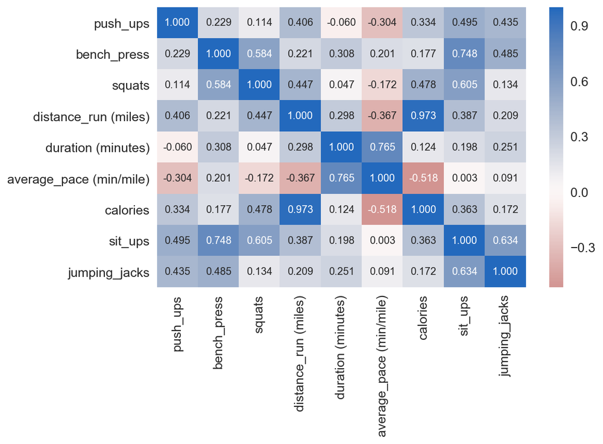

```python
# correlation plot
plt.figure(figsize = [8, 5])
sb.heatmap(fit[numeric_vars].corr(), annot = True, fmt = '.3f',
           cmap = 'vlag_r', center = 0)
plt.show()
```

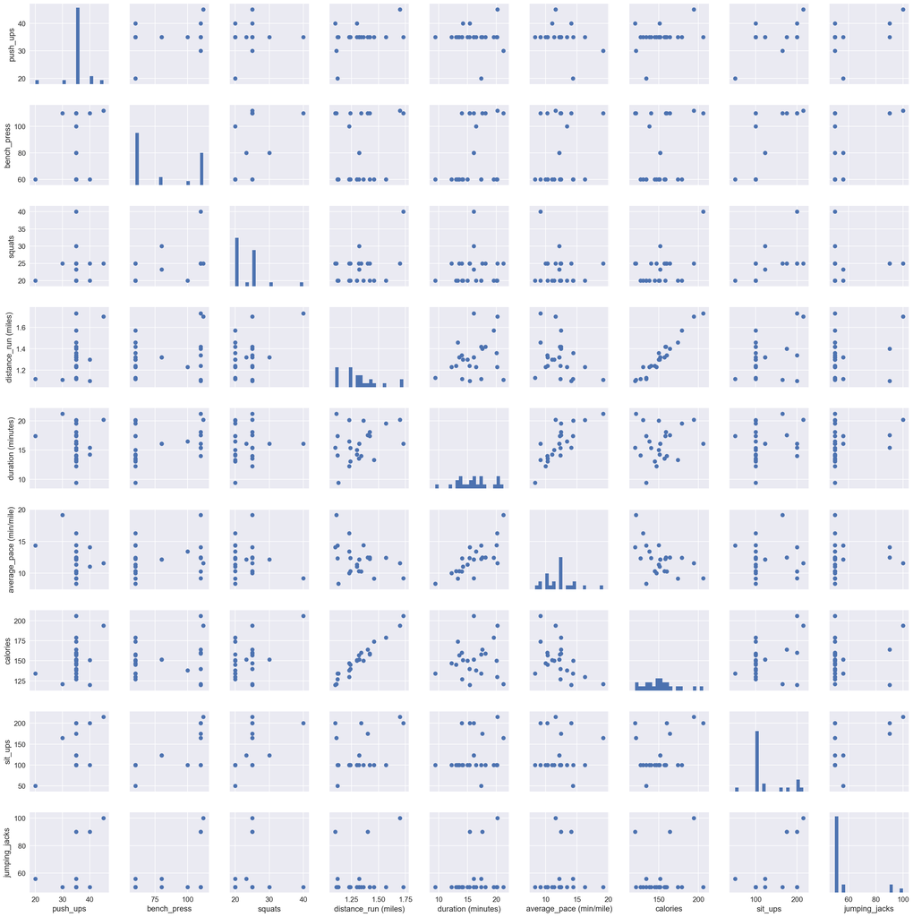

```python
# plot matrix: checking relationship between the numerical variables in the dataset

g = sb.PairGrid(data = fit, vars = numeric_vars)
g = g.map_diag(plt.hist, bins = 20);
g.map_offdiag(plt.scatter);
```

## PREDICTION AND VISUALIZATION

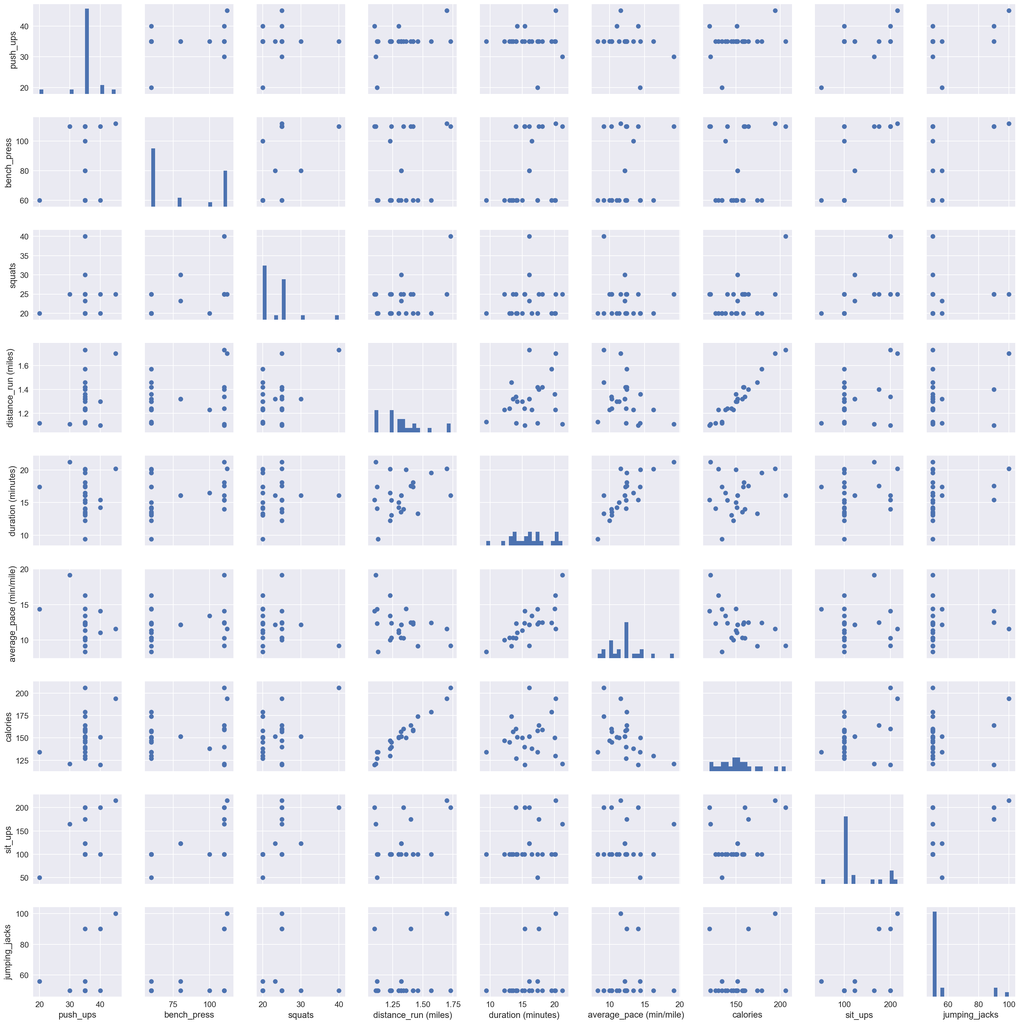

```python
# plot matrix: checking relationship between the numerical variables in the dataset

g = sb.PairGrid(data = fit, vars = numeric_vars)
g = g.map_diag(plt.hist, bins = 20);
g.map_offdiag(plt.scatter);
```

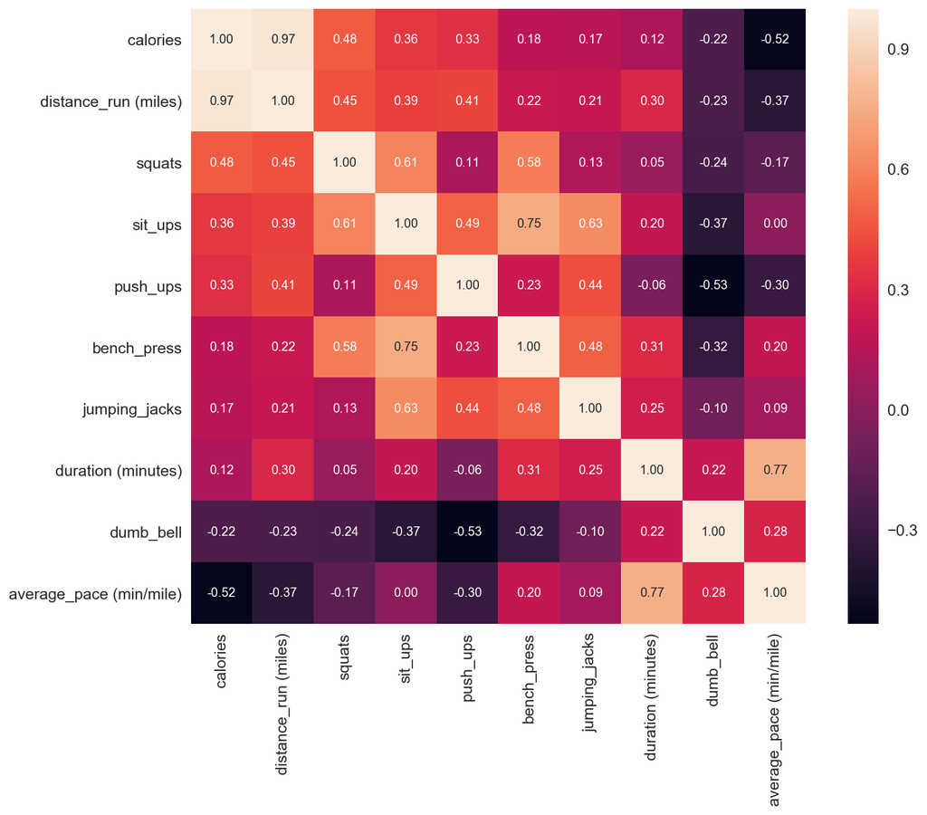

```python
#calories correlation matrix

corrmat = fit.corr()
f, ax = plt.subplots(figsize=(12, 9))
k = 11  #number of variables for heatmap
cols = corrmat.nlargest(k, 'calories')['calories'].index
cm = np.corrcoef(fit[cols].values.T)
sb.set(font_scale=1.25)
hm = sb.heatmap(cm, cbar=True, annot=True, square=True, fmt='.2f', annot_kws={'size': 10}, yticklabels=cols.values, xticklabels=cols.values)
plt.show()
```

### (1)REGRESSION MODEL

```python
X=fit[['push_ups','bench_press','squats','distance_run (miles)','duration (minutes)','average_pace (min/mile)','sit_ups','jumping_jacks']]
y=fit['calories']
```

```python
import sklearn
from sklearn.model_selection import train_test_split
```

```python
X_train,X_test,y_train,y_test=train_test_split(X,y,test_size=0.2,random_state=1)
```

```python
from sklearn.linear_model import LinearRegression
```

```python
reg=LinearRegression()
```

```python
reg.fit(X_train,y_train)
```

```
LinearRegression(copy_X=True, fit_intercept=True, n_jobs=1, normalize=False)
```

```python
print('Intercept:' , reg.intercept_)
print('Coefficients:', reg.coef_)
```

```
Intercept: 34.57969118511399
Coefficients: [-8.97711176e-01 -1.23337862e-02 -1.34942580e-02  1.28341763e+02
 -1.21244184e+00 -6.42088843e-01  3.20310449e-02  6.35041619e-02]
```

### PREDICTING WITH THE MODEL

```python
pred=reg.predict(X_train)
pred
```

```
array([151.61806218, 149.51674241, 127.25145125, 118.8306906 ,
       154.77982177, 161.81071008, 131.51678379, 145.07132801,
       191.94890089, 151.15187074, 122.54963708, 145.22968444,
       173.88161871, 207.47911907, 160.12517359, 137.27951561,
       149.89815624, 178.30969622, 134.20558275])
```

### (2) USING SKLEARN APPROACH

```python
from sklearn import linear_model
import statsmodels.api as sm
```

```python
# with sklearn
regr = linear_model.LinearRegression()
regr.fit(X, y)

print('Intercept:', regr.intercept_)
print('Coefficients:', regr.coef_)


# with statsmodels
x = sm.add_constant(X) # adding a constant

model = sm.OLS(y, X).fit()
predictions = model.predict(X)

print_model = model.summary()
print(print_model)
```

```
Intercept: 24.113061857701297
Coefficients: [-8.31834722e-01 -1.51387587e-02 -3.32148209e-02  1.34774951e+02
 -1.65617161e+00  8.56196405e-03  2.80545877e-02  6.63650501e-02]
                            OLS Regression Results
==============================================================================
Dep. Variable:               calories   R-squared:                       1.000
Model:                            OLS   Adj. R-squared:                  1.000
Method:                 Least Squares   F-statistic:                 1.427e+04
Date:                Sat, 12 Sep 2020   Prob (F-statistic):           2.45e-29
Time:                        16:01:52   Log-Likelihood:                -48.331
No. Observations:                  24   AIC:                             112.7
Df Residuals:                      16   BIC:                             122.1
Df Model:                           8
Covariance Type:            nonrobust
===========================================================================================
                              coef    std err          t      P>|t|      [0.025      0.975]
-------------------------------------------------------------------------------------------
push_ups                   -0.8222      0.157     -5.233      0.000      -1.155      -0.489
bench_press                -0.0098      0.033     -0.294      0.772      -0.081       0.061
squats                     -0.0609      0.176     -0.345      0.734      -0.434       0.313
distance_run (miles)      153.9819      6.546     23.525      0.000     140.106     167.858
duration (minutes)         -3.1712      0.542     -5.851      0.000      -4.320      -2.022
average_pace (min/mile)     1.9198      0.529      3.629      0.002       0.798       3.041
sit_ups                     0.0125      0.021      0.599      0.557      -0.032       0.057
jumping_jacks               0.0953      0.045      2.120      0.050       2e-05       0.191
==============================================================================
Omnibus:                        1.941   Durbin-Watson:                   1.927
Prob(Omnibus):                  0.379   Jarque-Bera (JB):                1.152
Skew:                          -0.536   Prob(JB):                        0.562
Kurtosis:                       3.043   Cond. No.                     2.47e+03
==============================================================================

Warnings:
[1] Standard Errors assume that the covariance matrix of the errors is correctly specified.
[2] The condition number is large, 2.47e+03. This might indicate that there are
strong multicollinearity or other numerical problems.
```

#### The part displays a comprehensive table with statistical info generated by statsmodels.

This information can provide you additional insights about the model used (such as the fit of the model, standard errors, etc):

### (3)Using statsmodels

```python
X = sm.add_constant(X) ## let's add an intercept (beta_0) to our model

# Note the difference in argument order
model = sm.OLS(y, X).fit() ## sm.OLS(output, input)
predictions = model.predict(X)

# Print out the statistics
model.summary()
```

OLS Regression Results

| Dep. Variable: | calories | R-squared: | 0.993 |
| --- | --- | --- | --- |
| Model: | OLS | Adj. R-squared: | 0.989 |
| Method: | Least Squares | F-statistic: | 270.1 |
| Date: | Sat, 12 Sep 2020 | Prob (F-statistic): | 8.52e-15 |
| Time: | 16:01:53 | Log-Likelihood: | -47.157 |
| No. Observations: | 24 | AIC: | 112.3 |
| Df Residuals: | 15 | BIC: | 122.9 |
| Df Model: | 8 |  |  |
| Covariance Type: | nonrobust |  |  |

|  | coef | std err | t | P>\|t\| | [0.025 | 0.975] |
| --- | --- | --- | --- | --- | --- | --- |
| const | 24.1131 | 19.420 | 1.242 | 0.233 | -17.280 | 65.507 |
| push_ups | -0.8318 | 0.155 | -5.376 | 0.000 | -1.162 | -0.502 |
| bench_press | -0.0151 | 0.033 | -0.457 | 0.654 | -0.086 | 0.055 |
| squats | -0.0332 | 0.175 | -0.190 | 0.852 | -0.406 | 0.339 |
| distance_run (miles) | 134.7750 | 16.755 | 8.044 | 0.000 | 99.062 | 170.487 |
| duration (minutes) | -1.6562 | 1.332 | -1.244 | 0.233 | -4.494 | 1.182 |
| average_pace (min/mile) | 0.0086 | 1.625 | 0.005 | 0.996 | -3.455 | 3.472 |
| sit_ups | 0.0281 | 0.024 | 1.166 | 0.262 | -0.023 | 0.079 |
| jumping_jacks | 0.0664 | 0.050 | 1.328 | 0.204 | -0.040 | 0.173 |

| Omnibus: | 1.518 | Durbin-Watson: | 2.123 |
| --- | --- | --- | --- |
| Prob(Omnibus): | 0.468 | Jarque-Bera (JB): | 0.529 |
| Skew: | -0.314 | Prob(JB): | 0.768 |
| Kurtosis: | 3.365 | Cond. No. | 9.63e+03 |

Warnings:  
[1] Standard Errors assume that the covariance matrix of the errors is correctly specified.  
[2] The condition number is large, 9.63e+03. This might indicate that there are  
strong multicollinearity or other numerical problems.

### RERUNNING REGRESSION ANALYSIS

```python
import statsmodels.api as sm # import statsmodels

X = fit[["push_ups","distance_run (miles)","duration (minutes)","jumping_jacks"]] ## X usually means our input variables (or independent variables)
y = fit["calories"] ## Y usually means our output/dependent variable
X = sm.add_constant(X) ## let's add an intercept (beta_0) to our model

# Note the difference in argument order
model = sm.OLS(y, X).fit() ## sm.OLS(output, input)
predictions = model.predict(X)

# Print out the statistics
model.summary()
```

OLS Regression Results

| Dep. Variable: | calories | R-squared: | 0.992 |
| --- | --- | --- | --- |
| Model: | OLS | Adj. R-squared: | 0.991 |
| Method: | Least Squares | F-statistic: | 604.9 |
| Date: | Sat, 12 Sep 2020 | Prob (F-statistic): | 9.74e-20 |
| Time: | 16:01:54 | Log-Likelihood: | -48.627 |
| No. Observations: | 24 | AIC: | 107.3 |
| Df Residuals: | 19 | BIC: | 113.1 |
| Df Model: | 4 |  |  |
| Covariance Type: | nonrobust |  |  |

|  | coef | std err | t | P>\|t\| | [0.025 | 0.975] |
| --- | --- | --- | --- | --- | --- | --- |
| const | 20.8342 | 4.676 | 4.456 | 0.000 | 11.048 | 30.621 |
| push_ups | -0.7695 | 0.129 | -5.944 | 0.000 | -1.040 | -0.499 |
| distance_run (miles) | 135.4682 | 2.959 | 45.784 | 0.000 | 129.275 | 141.661 |
| duration (minutes) | -1.6531 | 0.167 | -9.896 | 0.000 | -2.003 | -1.303 |
| jumping_jacks | 0.0967 | 0.034 | 2.812 | 0.011 | 0.025 | 0.169 |

| Omnibus: | 0.323 | Durbin-Watson: | 1.866 |
| --- | --- | --- | --- |
| Prob(Omnibus): | 0.851 | Jarque-Bera (JB): | 0.045 |
| Skew: | -0.104 | Prob(JB): | 0.978 |
| Kurtosis: | 2.959 | Cond. No. | 782. |

Warnings:  
[1] Standard Errors assume that the covariance matrix of the errors is correctly specified.

**MODEL COEFFICIENTS**

- calories = (Intercept) + (push_ups)X1 + (distance run/mile)X2 + (duration(min))X3 + (jumping_jacks)X4
- calories = (20.8342) + (-0.7695)X1 + (135.4682)X2 + (-1.6531)X3 + (0.0967)X4

**Interpreting the Output**

We can see here that this model has a very high R-squared value of 99.2%, meaning that this model explains 99.2% of the variance in our dependent variable. Whenever we add variables to a regression model, R² will be higher, but this is a pretty high R². Overall the model is a good fit of the data.

The value of calories when all variables are kept constant is 20.8342. We can see that push ups, distance run/mile, duration(min), and jumping jacks are all statistically significant in predicting (or estimating) the median calories burnt; we see that as push ups increases by 1 unit, calories will decrease by 0.7695 and vice versa keeping the remaining variables constant; also when distance run/mile increases by 1 unit, calories will increase by 135.47 and vice versa keeping the remaining variables constant; also when duration(min) increases by 1 unit, calories will decrease by 1.6531 and vice versa keeping the remaining variables constant; and lastly when jumping jacks increases by 1 unit, calories will increase by 0.0967 and vice versa keeping the remaining variables constant

**PREDICTING USING THE MODEL**

```python
# Try to predict the y ( balance) for the test data-features(independentvariables(x_test))
predictions=reg.predict(X_test)
```

```python
# Accuracy of the prediction
confidence = reg.score(X_test, y_test)
print("This is predicted Values",predictions)
print("This is the prediction accuracy",confidence)
```

```
This is predicted Values [140.4342046  159.44454403 163.15555176 146.54222812 136.80241824]
This is the prediction accuracy 0.955674883678814
```

```
No handles with labels found to put in legend.
```

```
Text(0,0.5,'calories_Predict')
```

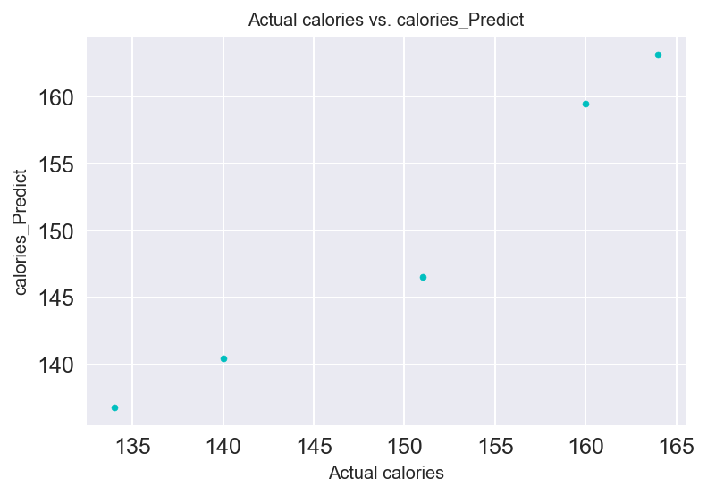

```python
plt.legend(loc=4)
plt.title("Actual calories vs. calories_Predict", size=10)
plt.scatter(y_test,predictions,color='c', marker='.')
plt.xlabel("Actual calories", size=10)
plt.ylabel("calories_Predict", size=10)
```

### CONCLUSION

**All four variables statistically significantly predicted calories burnt**

## REGRESSION ANALYSIS TWO

```python
import statsmodels.api as sm # import statsmodels

X = fit[["distance_run (miles)","average_pace (min/mile)"]] ## X usually means our input variables (or independent variables)
y = fit["duration (minutes)"] ## Y usually means our output/dependent variable
X = sm.add_constant(X) ## let's add an intercept (beta_0) to our model

# Note the difference in argument order
model = sm.OLS(y, X).fit() ## sm.OLS(output, input)
predictions = model.predict(X)

# Print out the statistics
model.summary()
```

OLS Regression Results

| Dep. Variable: | duration (minutes) | R-squared: | 0.973 |
| --- | --- | --- | --- |
| Model: | OLS | Adj. R-squared: | 0.971 |
| Method: | Least Squares | F-statistic: | 379.6 |
| Date: | Sat, 12 Sep 2020 | Prob (F-statistic): | 3.28e-17 |
| Time: | 16:01:59 | Log-Likelihood: | -15.765 |
| No. Observations: | 24 | AIC: | 37.53 |
| Df Residuals: | 21 | BIC: | 41.06 |
| Df Model: | 2 |  |  |
| Covariance Type: | nonrobust |  |  |

|  | coef | std err | t | P>\|t\| | [0.025 | 0.975] |
| --- | --- | --- | --- | --- | --- | --- |
| const | -13.9265 | 1.203 | -11.579 | 0.000 | -16.428 | -11.425 |
| distance_run (miles) | 11.3925 | 0.655 | 17.381 | 0.000 | 10.029 | 12.756 |
| average_pace (min/mile) | 1.2289 | 0.047 | 26.264 | 0.000 | 1.132 | 1.326 |

| Omnibus: | 2.067 | Durbin-Watson: | 1.695 |
| --- | --- | --- | --- |
| Prob(Omnibus): | 0.356 | Jarque-Bera (JB): | 0.993 |
| Skew: | -0.476 | Prob(JB): | 0.609 |
| Kurtosis: | 3.296 | Cond. No. | 165. |

Warnings:  
[1] Standard Errors assume that the covariance matrix of the errors is correctly specified.